# Determination of oxygen mass transfer coefficient (KLa) in batch reactor airation

Rafael Ventura

9th July of 2017

## Objectives

Exercise on the statement of a model, programming in AQUASIM, and devising a strategy for parameter fitting.

Assignment is part of evaluation of Modelling Sanitation Systems Online course.

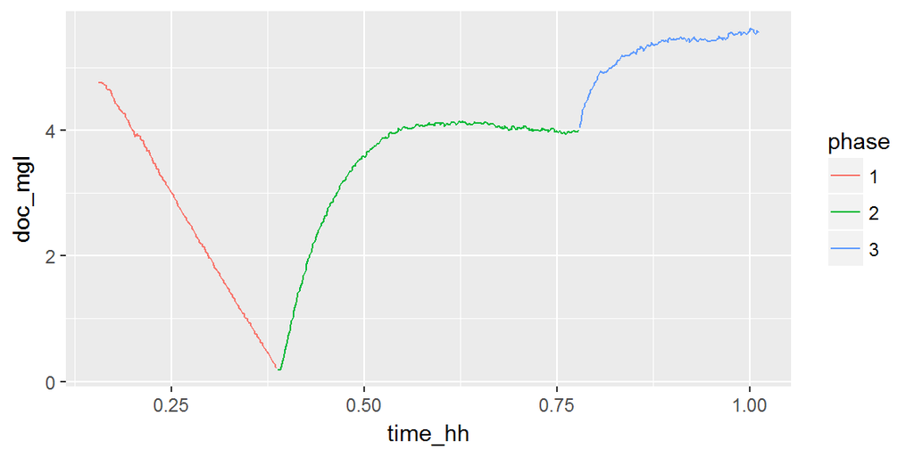

Endogenous respiration- phase I

## Procedure

- First, oxygen uptake rate is obtained from data by fitting a linear model to data in phase I

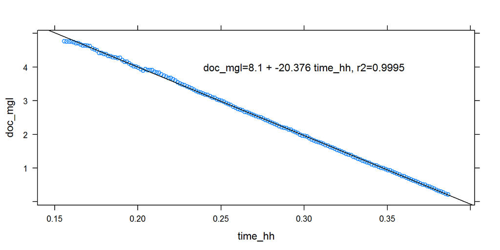

  QO2 estimation- Phase 1 data

```
## [1] "QO2 =  -20.376  [mg/L-h] "
```

- Second, initial condition for SO (SO_ini) for AQUASIM simulation is read from data at phase II, by retrieving the minimum value in phase II.

```
## [1] "SO_ini = 0.189951 [mg/L]"
```

- Third, dissolved Oxygen concentration at equilibrium is read from data in phase II as the maximum value:

```
## [1] "SO_eq = 4.14821 [mg/L]"
```

- Fourth, we obtained SO_sat from data in phase III, when SO reached its maximum

```
## [1] "SO_sat = 5.6198 [mg/L]"
```

As substrate is depleted, Biomass undergoes endogenous respiration process in phase 1. As stated in problem definition, OUR is constant.

```
## [1] "KLa =  13.846  [1/h]"
```

**Simulation with AQUASIM**

State variable are dissolved oxygen concentration in liquid phase(SO) and oxygen concentration in gas phase, both in [mg/L]. Process variable is time in [h].

Process are defined as two reactions:

$K_{La}*(SO_sat - SO)$ for oxygen mass transfer during airation,

Biomass Heterotrophic growth is not considered as substrate is depleted. For airation, KLa and SO_sat are set to be 13,846 [1/h] and 5,6198 [mg/L], from calculations mentioned above. Reactor volumen is set to be 1,64 [L]. Petersen matrix is shown below:

Petersen matrix.

| process | SO | Expr |
| --- | --- | --- |
| Airation | 1 | KLa*(SO_sat - SO) |
| Decay | -1 | QO2 |

For endogenous respiration (decay) process’s reaction rate, QO2 was estimated above.

A compartment is defined as a CSRT with airation and decay process activated. An inflow of air to compartment with no water flow but gas with O2 concentration (SG) equal to 203 [mg/L]. SG is calculated using the Ideal gas law: $SG = PO/RT$ at with appropriate units.

Neither diffusive nor adventive link are considered.

Simulation time interval simulation was set to be 0.001 [h] ranging and 400 steps.

## Sensitivity Analysis

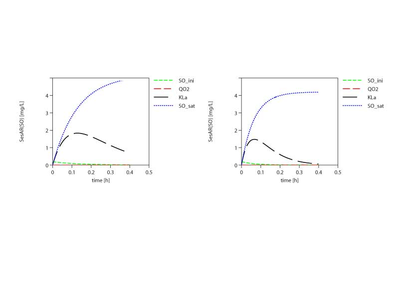

AQUASIM SO Sensitivity analysis with parameters

## Model parameters adjustment

The strategy is fitting SO_sat and KLa, simultaneouly. Results are shown in Table 2.

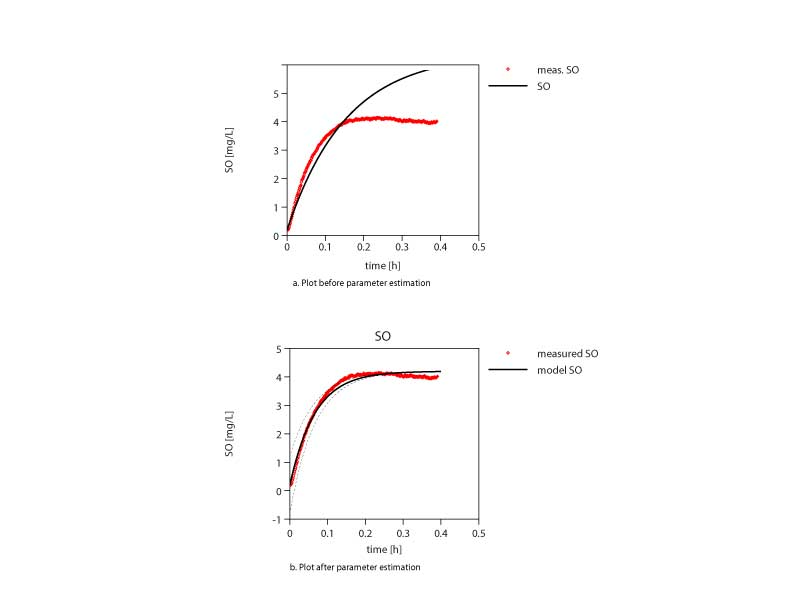

AQUASIM Simulation run #3

Parameter fitting with AQUASIM.

| parameter | Initial_Estimation | Fitted_Value | ChiSqr |
| --- | --- | --- | --- |
| SO_ini [mg/L] | 0,189951 | 0,189951 | NA |
| Q2O [mg/L-h] | -20,376447 | -20,376447 | NA |
| SO_sat [mg/L] | 5,6198 | 4,1992 | 5,0473533 |
| KLa [1/h] | 13,846 | 15,000 | 5,0473533 |

Simulation file can be found at the following link: Dropbox (https://www.dropbox.com/s/jt96iv8p5yep26w/oxygen-mass-transfer-sensitivity-analysis-2.lis?dl=0)